# Growth in the cross-section (of countries)

**NOTE**: The present notebook is coded in R. It relies heavily on the [**tidyverse**](https://www.tidyverse.org/) ecosystem of packages. We load the tidyverse below as a prerequisite for the rest of the notebook - along with a few other libraries.

$\rightarrow$ Don’t forget that code flows **sequentially**. A random chunk may not work if the previous have have not been executed.

```r
library(tidyverse)    # Package for data wrangling
library(readxl)       # Package to import MS Excel files
library(latex2exp)    # Package for LaTeX expressions
library(quantmod)     # Package for stock data extraction
library(highcharter)  # Package for reactive plots
library(ggcorrplot)   # Package for correlation plots
library(ggrepel)      # Package for neat annotations
library(plm)          # Package for panel models
library(fixest)       # Other Package for panels
library(reactable)    # Package for neat tables
library(WDI)          # Package for World Bank data
library(broom)        # Package for neat regression output
library(tidyfit)      # Package for grouped regressions
library(httr)         # package to fetch data online
impute <- function(v, n = 6){     # Imputation function
  for(j in 1:n){
    ind <- which(is.na(v))
    if(length(ind)>0){
      if(ind[1]==1){ind <- ind[-1]}
      v[ind] <- v[ind-1]
    }
  }
  return(v)
}
```

The content of the notebook is heavily inspired from the book [**Advanced Macro-economics - An Easy Guide**](https://press.lse.ac.uk/site/books/m/10.31389/lsepress.ame/).

# Introduction

Until now, we have sought to explain growth through particular lenses (human capital, technology) but have mostly failed to do so.

In this session/notebook, we are interested in a broader and much more **data-centric** approach. We seek to analyze a large cross-section of countries as well as **many explanatory factors** at the **same time**.

# Foundations

**NoteTheory (sort of)**

Suppose that in all generality, the **production function** is a generalization of the Cobb-Douglas (multiplicative) form:

$$Y=\prod_{n=1}^N X_n^{a_n}, \quad X_n >0, \quad a_n >0,$$
so that we envision $N$ different **factors** contributing to the economic output. Note that returns to scale are determined by $\sum_{n=1}^Na_n$.
Taking the logarithm:
$$\log(Y) = \sum_{n=1}^N a_n \log(X_n)$$
and differentiating (w.r.t. time) yields

$$\frac{\dot{Y}}{Y} = \sum_{n=1}^N a_n \frac{\dot{X}}{X}.$$

This is a sound grounding for simple (linear) **regression models** which we’ll cover below.

## Fetching & wrangling the data

Below, we extract a sufficient number (~10) of potential predictors of growth and **impute** a few points along the way (to increase sample size).

```r
wb_raw <- WDI(                              # World Bank data
  indicator = c(
    "labor" = "SL.TLF.TOTL.IN",             # Labor force (# individuals)
    "savings_rate" = "NY.GDS.TOTL.ZS",      # Savings rate (% GDP)
    "inflation" = "FP.CPI.TOTL.ZG",         # Inflation rate
    "trade" = "NE.TRD.GNFS.ZS",             # Trade as % of GDP
    "pop" = "SP.POP.TOTL",                  # Population
    "pop_growth" = "SP.POP.GROW",           # Population growth
    "capital_formation" = "NE.GDI.TOTL.ZS", # Gross capital formation (% GDP)
    "gdp_percap" = "NY.GDP.PCAP.CD",        # GDP per capita
    "RD_percap" = "GB.XPD.RSDV.GD.ZS",      # R&D per capita
    "educ_level" = "SE.SEC.CUAT.LO.ZS",     # % pop reachiing second. educ. level
    "educ_spending" = "SE.XPD.TOTL.GD.ZS",  # Education spending (%GDP)
    "nb_researchers" = "SP.POP.SCIE.RD.P6", # Nb researchers per million inhab.
    "debt" = "GC.DOD.TOTL.GD.ZS",           # Central gov. debt (% of GDP)
    "gdp" = "NY.GDP.MKTP.CD"                # Gross Domestic Product (GDP)
  ),
  extra = TRUE,
  start = 1960,
  end = 2024) |>
  mutate(across(everything(), as.vector)) |>
  select(-status, -lending, -iso2c, -iso3c) |>
  filter(region != "Aggregates", income != "Aggregates") |>
  arrange(country, year) |>
  group_by(country) |>
  mutate(across(everything(), impute)) |>
  mutate(gdp_growth = gdp_percap/dplyr::lag(gdp_percap) - 1,
        .before = "region") |>
  mutate(gdp_percap = log(lag(gdp_percap))) |>       # log-lag transformation
  ungroup() |>
  filter(lastupdated == max(lastupdated)) |>
  arrange(country, year) |>
  mutate(capital_percap = capital_formation / labor, .before = "region")
```

We make a few adjustments to the data, adding GDP per capita growth.

```r
wb_growth <- wb_raw |>
  filter(region != "Aggregates", income != "Aggregates")

wb_growth |> tail(3)
```

| country | year | lastupdated | labor | savings_rate | inflation | trade | pop | pop_growth | capital_formation | gdp_percap | RD_percap | educ_level | educ_spending | nb_researchers | debt | gdp | gdp_growth | capital_percap | region | capital | longitude | latitude | income |
| --- | --- | --- | --- | --- | --- | --- | --- | --- | --- | --- | --- | --- | --- | --- | --- | --- | --- | --- | --- | --- | --- | --- | --- |
| Zimbabwe | 2022 | 2025-10-07 | 6118687 | 5.591073 | 104.7052 | 64.76361 | 16069056 | 1.706209 | 14.610339 | 7.620973 | NA | 64.94 | 2.0504899 | NA | NA | 32789657378 | 0.1833459 | 2.4e-06 | Sub-Saharan Africa | Harare | 31.0672 | -17.8312 | Lower middle income |
| Zimbabwe | 2023 | 2025-10-07 | 6232464 | 8.637877 | 104.7052 | 50.79496 | 16340822 | 1.677096 | 16.274040 | 7.676026 | NA | 64.94 | 0.3847713 | NA | NA | 35231369343 | 0.0565964 | 2.6e-06 | Sub-Saharan Africa | Harare | 31.0672 | -17.8312 | Lower middle income |
| Zimbabwe | 2024 | 2025-10-07 | 6386440 | -3.993908 | 104.7052 | 52.67301 | 16634373 | 1.780482 | 4.467751 | 7.884731 | NA | NA | 0.3847713 | NA | NA | 44187704410 | 0.2320813 | 7.0e-07 | Sub-Saharan Africa | Harare | 31.0672 | -17.8312 | Lower middle income |

## First analyses

Let’s have a look at missing data, **after imputation**!.  
In some cases, when no data exists, **forward-filling** is not possible.

```r
wb_growth |> select() |> is.na() |> colMeans()
```

```
numeric(0)
```

```r
vars <- c("gdp_percap", "savings_rate", "inflation", "trade", "capital_formation" , "pop_growth", "educ_level", "educ_spending")
```

**Debt** and **R&D** cost a lot of data depletion: we will remove them from the analysis.  
Which countries are the most represented in the sample (with no missing point, *after imputation*)?

```r
wb_growth |>
  select(all_of(c(vars, "country"))) |>
  na.omit() |>
  group_by(country) |>
  count(sort = T) |>
  head(13)
```

| country | n |
| --- | --- |
| Canada | 54 |
| Portugal | 45 |
| Spain | 44 |
| Korea, Rep. | 43 |
| Sweden | 42 |
| Ecuador | 41 |
| Italy | 38 |
| Chile | 35 |
| Israel | 35 |
| Ireland | 34 |
| Indonesia | 32 |
| Mexico | 32 |
| Czechia | 31 |

Next, let us look if there is **colinearity** among variables. Indeed, high correlations between independent variables are likely to perturb inference.

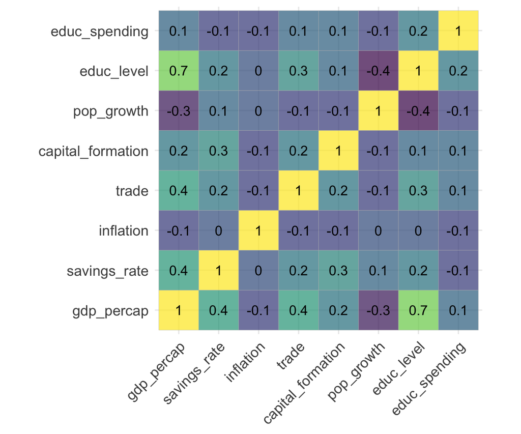

```r
wb_growth |>
  select(all_of(vars)) |>
  #na.omit() |>
  cor(use = "pairwise.complete") |>
  ggcorrplot(lab = TRUE, digits = 1L) +
  scale_fill_viridis_c(alpha = 0.7) +
  theme(legend.position = "none")
```

Usually, a correlation of 0.5 (in absolute value) is considered already high. A value above 0.7 is prohibitive…  
So here, it seems we are relatively fine (education and GDP per capita are close, though).

Let’s have a brief look at numbers; take inflation.  
Are there outliers or false values?

```r
wb_raw |>
  group_by(country) |>
  summarise(avg_inflation = mean(inflation, na.rm = T)) |>
  na.omit() |> head(9)
```

| country | avg_inflation |
| --- | --- |
| Afghanistan | 4.862333 |
| Albania | 2.599840 |
| Algeria | 5.018634 |
| Angola | 22.210968 |
| Antigua and Barbuda | 2.430727 |
| Argentina | 86.293375 |
| Armenia | 3.251960 |
| Aruba | 2.672916 |
| Australia | 4.679567 |

# Panel models

We now turn to an exploration of the concepts and variables seen and mentioned until today. Indeed, models are only worthwhile if they are able to explain (or predict) salient empirical properties of the economy.

**NoteNote**

We follow here a panel approach from [Economic Growth in a Cross Section of Countries](https://academic.oup.com/qje/article-abstract/106/2/407/1905452), though we apply it to GDP per capita and not to *raw* GDP:

$$g_{t,i}=\textbf{X}_{t,i}\boldsymbol{\beta}+a \log(y_{t-1,i}) + e_{t,i},$$

where $g_{t,i}$ is the growth rate of country $i$ at date (year) $t$ and $y_{t,i}$ is GDP per capita. The matrix $\textbf{X}_{t,i}$ embeds all variables of interest.

## Baseline estimation

As a first attempt, we proceed with the traditional two-way fixed effect (**TWFE**) model, meaning that the equation is:
$$g_{t,i}=\textbf{X}_{t,i}\boldsymbol{\beta}+a \log(y_{t-1,i}) + b_i + c_t + e_{t,i},$$
where the errors have zero means and the $b_i$ and $c_t$ are dummy variables that code the **company** and **year** rows, respectively.

The `{plm}` package is likely the most used for panel models in R. We use it below (at first).

```r
plm_data <- wb_growth |> dplyr::select(all_of(c("country", "year", "gdp_growth", "pop", vars))) |>
  na.omit() |> group_by(country) |> mutate(n = n()) |> filter(n > 21) |> select(-n) |> ungroup()
fit_two_way <- plm(formula = gdp_growth ~ . ,
                   data = plm_data,
                   model = "within", effect = "twoways",
                   index = c("country", "year"))
# summary(fit_two_way) # PLM hints towards singularity, upon verification, this is false...
```

We also store the results for future use.

```r
fit_two_way <- fit_two_way$coef |> data.frame() |>
  rownames_to_column(var = "variable") |>
  mutate(type = "two_way")
colnames(fit_two_way)[2] <- "estimate"
```

To detect which variables matter, we look at *p*-values: they indicate the probability to obtain a value as “extreme” as the one observed under the assumption that the coefficient is equal to zero (this hypothesis is called the **null**). Hence if a *p*-value is close to zero, it signals support for the assumption that there is a link (not necessarily causal) between the dependent and independent variables.

## Mono effect models

Below, we test to see the results remain robust if we only consider one dimension of effects.

```r
fit_indiv <- plm(formula = gdp_growth ~ . ,
                 data = plm_data,
                 model = "within", effect = "individual",
                 index = c("country", "year"))$coef |> data.frame() |>
  rownames_to_column(var = "variable") |>
  mutate(type = "indiv")
colnames(fit_indiv)[2] <- "estimate"
fit_time <- plm(formula = gdp_growth ~ . ,
                data = plm_data,
                model = "within", effect = "time",
                index = c("country", "year"))$coef |> data.frame() |>
  rownames_to_column(var = "variable") |>
  mutate(type = "time")
colnames(fit_time)[2] <- "estimate"
```

Let’s see the **differences** between models.

```r
fit_two_way |>
  bind_rows(fit_indiv) |>
  bind_rows(fit_time) |>
  filter(variable %in% vars) |> select(variable, estimate, type) |>
  pivot_wider(names_from = type, values_from = estimate)
```

| variable | two_way | indiv | time |
| --- | --- | --- | --- |
| gdp_percap | -0.0085779 | -0.0085779 | -0.0085779 |
| savings_rate | 0.0039724 | 0.0039724 | 0.0039724 |
| inflation | -0.0002962 | -0.0002962 | -0.0002962 |
| trade | -0.0006141 | -0.0006141 | -0.0006141 |
| capital_formation | 0.0022876 | 0.0022876 | 0.0022876 |
| pop_growth | -0.0222256 | -0.0222256 | -0.0222256 |
| educ_level | -0.0002145 | -0.0002145 | -0.0002145 |
| educ_spending | -0.0078161 | -0.0078161 | -0.0078161 |

The values are *identical*. This should not be the case; there must be a **problem** here!  
We thus repeat this exercise, but with another library, the `{fixest}` package.

```r
fml_0 <- "gdp_growth ~ gdp_percap + savings_rate + inflation + trade + "
fml_0 <- paste(fml_0, "capital_formation + pop_growth + educ_level + educ_spending")
fml <- as.formula(paste(fml_0, "| year"))
fit_time <- ((feols(fml, data = plm_data)$coefficients)/sqrt(diag(feols(fml, data = plm_data)$cov.iid))) |>
  data.frame() |> rownames_to_column(var = "variable") |> mutate(type = "time")
colnames(fit_time)[2] <- "statistic"

fml <- as.formula(paste(fml_0, "| country"))
fit_indiv <- ((feols(fml, data = plm_data)$coefficients)/sqrt(diag(feols(fml, data = plm_data)$cov.iid))) |>
  data.frame() |> rownames_to_column(var = "variable") |> mutate(type = "indiv")
colnames(fit_indiv)[2] <- "statistic"

fml <- as.formula(paste(fml_0, "| country + year"))
fit_twoway <- ((feols(fml , data = plm_data)$coefficients)/sqrt(diag(feols(fml, data = plm_data)$cov.iid))) |>
  data.frame() |> rownames_to_column(var = "variable") |> mutate(type = "two_way")
colnames(fit_twoway)[2] <- "statistic"
```

**NOTE** that we store test statistics here and not raw coefficients. The former carry more information…

```r
fit_twoway |>
  bind_rows(fit_time) |>
  bind_rows(fit_indiv) |>
  pivot_wider(names_from = type, values_from = statistic)
```

| variable | two_way | time | indiv |
| --- | --- | --- | --- |
| gdp_percap | -0.6361210 | -4.636578 | -2.573712 |
| savings_rate | 5.1617455 | 3.516396 | 4.692063 |
| inflation | -4.5424615 | -4.443799 | -4.147527 |
| trade | -2.8608038 | -0.198431 | -1.078309 |
| capital_formation | 1.7947934 | 3.517437 | 4.001261 |
| pop_growth | -3.2777516 | -4.395138 | -2.000779 |
| educ_level | -0.6274451 | 1.053713 | -1.228028 |
| educ_spending | -2.0060849 | -1.457869 | -3.083658 |

Ok, so now we do find some differences in **test statistics**. The good news is that signs are mostly consistent across most variables.  
But there are a few conflicts, too. There can be of two types:

- either the sign changes between the models;
- or the significance level changes (e.g., if some models have t-stats above 2 in absolute values, while others do not).

## Grouping

Until now, we have run the models on *all* of the data, but we could also consider sub-groups, either geographical ones, or income clusters. We could use grouping (in `{tidyverse}`/`{dplyr}` parlance) below, but in fact, for lower income countries, **we do not have enough data points** to proceed with estimation…

Indeed, if we look at the full sample,

```r
wb_growth |> group_by(income) |> count()
```

| income | n |
| --- | --- |
| High income | 5460 |
| Low income | 1625 |
| Lower middle income | 3315 |
| Not classified | 65 |
| Upper middle income | 3510 |

```r
# wb_growth |> group_by(region) |> count()
```

It may seem manageable; but if we impose non-missing points…  
Then the story is a bit different.

```r
wb_growth |> na.omit() |> group_by(income) |> count()
```

| income | n |
| --- | --- |
| High income | 236 |
| Low income | 20 |
| Lower middle income | 64 |
| Upper middle income | 250 |

```r
# wb_growth |> na.omit() |> group_by(region) |> count()
```

The sample size becomes too small. Indeed, recall that with fixed effects, when estimated with OLS, the **number of columns** increases by a lot (+ number of countries + number of years in the sample).

Let’s proceed with *manual* filters.

```r
plm_rich <- wb_growth |> filter(income == "High income") |>
  dplyr::select(all_of(c("country", "year", "gdp_growth", vars))) |>
  na.omit() |> group_by(country) |> mutate(n = n()) |> filter(n > 8) |> select(-n)
fit_rich <- ((feols(fml, data = plm_rich)$coefficients)/sqrt(diag(feols(fml, data = plm_rich)$cov.iid))) |>
  data.frame() |> rownames_to_column(var = "variable") |> mutate(income = "rich")
colnames(fit_rich)[2] <- "statistic"

plm_mid <- wb_growth |> filter(income == "Upper middle income") |>
  dplyr::select(all_of(c("country", "year", "gdp_growth", vars))) |>
  na.omit() |> group_by(country) |> mutate(n = n()) |> filter(n > 8) |> select(-n)
fit_mid <- ((feols(fml, data = plm_mid)$coefficients)/sqrt(diag(feols(fml, data = plm_mid)$cov.iid))) |>
  data.frame() |> rownames_to_column(var = "variable") |> mutate(income = "middle")
colnames(fit_mid)[2] <- "statistic"

fit_rich |> bind_rows(fit_mid) |> pivot_wider(names_from = income, values_from = statistic)
```

| variable | rich | middle |
| --- | --- | --- |
| gdp_percap | -2.3797800 | -0.0406204 |
| savings_rate | 8.8445465 | 5.6322502 |
| inflation | -4.6128496 | -2.0029601 |
| trade | -3.1693687 | -0.3766862 |
| capital_formation | 1.5203099 | -1.0265394 |
| pop_growth | -5.4839572 | -2.1934949 |
| educ_level | -1.0358756 | 0.7645079 |
| educ_spending | 0.5128888 | -1.8905733 |

Pretty consistent! Except perhaps for a few variables…

## Predictive models

The above regression model seeks to link growth with **contemporaneous** variables. But we could also be interested in **lagged** predictors. To examine if some characteristics of nations imply **future** growth. Because most features are persistent (highly autocorrelated), we should not see too much difference. But the devil can be in the details… and in the lags!

```r
# To be done/discussed in class => grouping!
```

# Country-specific estimates

Until now, estimations were **grouped**: we used the information in the cross-section of firms (and chronology) to see the “global” effect of some variables on growth. But perhaps is this effect country-specific? (or even maybe time-dependent).

Below, we run the same regressions (in terms of ‘independent’ variables), but we will display results one variable at a time. The models are nevertheless **multivariate**.

```r
fit_countries <- wb_growth |>
  dplyr::select(all_of(c("country", "year", "gdp_growth", vars))) |>
  na.omit() |>
  group_by(country) |>
  mutate(n = n()) |>
  filter(n > 20) |>
  select(-year) |>
  regress(gdp_growth ~ ., m("lm")) |>
  coef()
```

Let’s have a look at a few variables.

First, **population growth**.

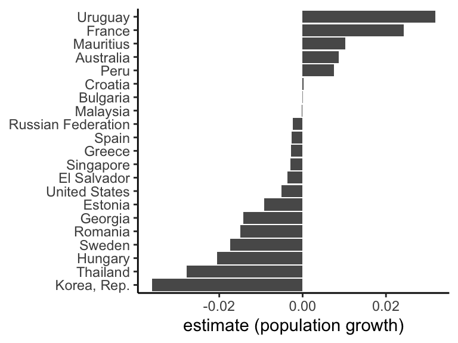

```r
fit_countries |>
  filter(term == "pop_growth") |>
  ggplot(aes(x = estimate, y = reorder(country, estimate))) + geom_col() +
  theme_classic() + theme(axis.title.y = element_blank()) +
  xlab("estimate (population growth)")
```

A majority of estimates are negative, with a handful of exceptions, including France.

What about **capital formation**?

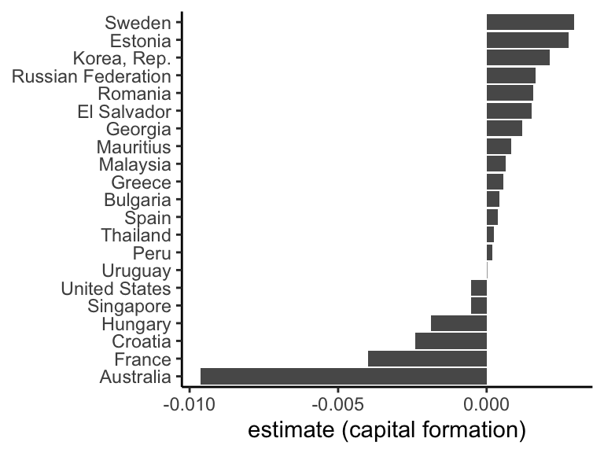

```r
fit_countries |>
  filter(term == "capital_formation") |>
  ggplot(aes(x = estimate, y = reorder(country, estimate))) + geom_col() +
  theme_classic() + theme(axis.title.y = element_blank()) +
  xlab("estimate (capital formation)")
```

Finally, a focus on the **savings rate**.

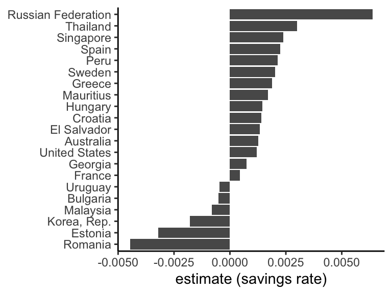

```r
fit_countries |>
  filter(term == "savings_rate") |>
  ggplot(aes(x = estimate, y = reorder(country, estimate))) + geom_col() +
  theme_classic() + theme(axis.title.y = element_blank()) +
  xlab("estimate (savings rate)")
```

Again, a split that is not evenly balanced; which both suggest some consistency and some exceptions.  
Hard to find a pattern, though (Eastern Europe is represented for the negative coefficients, but nothing jumps to the eye).

# Data sources outside the World Bank

The [Energy Institute](https://www.energyinst.org/statistical-review/resources-and-data-downloads) compiles a valuable (& updated) [dataset](https://www.energyinst.org/__data/assets/excel_doc/0006/1656348/Statistical-Review-of-World-Energy-Data.xlsx) on energy production by source. The data is too rich (90 variables), hence we restrict it to a few items.

```r
df <- read_excel("Statistical-Review-of-World-Energy-Data.xlsx")
data_energy <- df |>
  select(-ISO3166_alpha3, -ISO3166_numeric, -ISO3166_numeric, -CIS) |>
  mutate(Var = Var |> str_replace_all("_ej", "")) |>
  filter(Var %in% c("oilcons", "gascons", "coalcons", "renewables"))
colnames(data_energy) <- tolower(colnames(data_energy))
head(data_energy)
```

| country | year | region | subregion | opec | eu | oecd | var | value |
| --- | --- | --- | --- | --- | --- | --- | --- | --- |
| Algeria | 1965 | Africa | Northern Africa | 1 | 0 | 0 | coalcons | 0.0029308 |
| Algeria | 1965 | Africa | Northern Africa | 1 | 0 | 0 | gascons | 0.0267498 |
| Algeria | 1965 | Africa | Northern Africa | 1 | 0 | 0 | oilcons | 0.0554589 |
| Algeria | 1965 | Africa | Northern Africa | 1 | 0 | 0 | renewables | 0.0014400 |
| Algeria | 1966 | Africa | Northern Africa | 1 | 0 | 0 | coalcons | 0.0028470 |
| Algeria | 1966 | Africa | Northern Africa | 1 | 0 | 0 | gascons | 0.0277893 |

**NOTE**: “ej” means [**exajoules**](https://en.wikipedia.org/wiki/Joule#History) (=$10^{18}$J). It’s an important unit in physics and energy-related data.

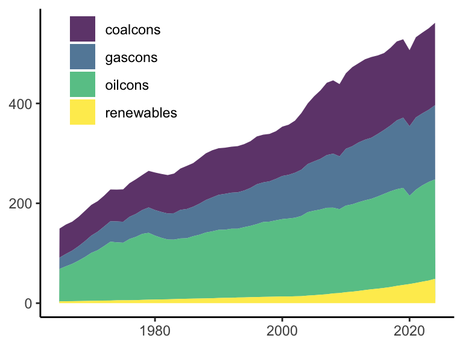

```r
data_energy |>
  filter(country == "Total World") |>
  ggplot(aes(x = year, y = value, fill = var)) + geom_area(alpha = 0.8) +
  theme_classic() +
  theme(axis.title = element_blank(),
        legend.title = element_blank(),
        legend.position = c(0.2, 0.8)) +
  scale_fill_viridis_d()
```

We then need to **join** this data with the WB data…  
(with a snapshot at the outome)

```r
data_energy_wide <- data_energy |>
  pivot_wider(names_from = var, values_from = value)
data_join <- plm_data |>
  full_join(data_energy_wide, by = c("year", "country"))
data_join |> na.omit() |> select(-region, -subregion) |> head()
```

| country | year | gdp_growth | pop | gdp_percap | savings_rate | inflation | trade | capital_formation | pop_growth | educ_level | educ_spending | opec | eu | oecd | coalcons | gascons | oilcons | renewables |
| --- | --- | --- | --- | --- | --- | --- | --- | --- | --- | --- | --- | --- | --- | --- | --- | --- | --- | --- |
| Brazil | 2001 | -0.1567108 | 176301203 | 8.063469 | 16.54900 | 6.840359 | 26.93629 | 18.74186 | 1.303355 | 37.80 | 3.84468 | 0 | 0 | 0 | 0.5356368 | 0.4423030 | 3.981208 | 1.316308 |
| Brazil | 2002 | -0.1008564 | 178503484 | 7.957156 | 18.29190 | 8.450164 | 27.61836 | 17.44908 | 1.241421 | 39.20 | 3.75037 | 0 | 0 | 0 | 0.5184374 | 0.5225851 | 3.885513 | 1.416803 |
| Brazil | 2003 | 0.0821680 | 180622688 | 8.036123 | 19.07787 | 14.714920 | 28.14038 | 16.85669 | 1.180214 | 40.80 | 3.75037 | 0 | 0 | 0 | 0.5379074 | 0.5849025 | 3.743762 | 1.492475 |
| Brazil | 2004 | 0.1854704 | 182675143 | 8.206262 | 21.32584 | 6.597185 | 29.67825 | 17.91257 | 1.129914 | 42.41 | 3.97448 | 0 | 0 | 0 | 0.5639648 | 0.6956094 | 3.873170 | 1.583042 |
| Brazil | 2005 | 0.3176896 | 184688101 | 8.482142 | 20.60575 | 6.869537 | 27.08680 | 17.20488 | 1.095906 | 43.10 | 4.47908 | 0 | 0 | 0 | 0.5439045 | 0.7245762 | 3.939635 | 1.670693 |
| Brazil | 2006 | 0.2291659 | 186653106 | 8.688478 | 20.52341 | 4.183568 | 26.04170 | 17.81647 | 1.058338 | 45.46 | 4.87060 | 0 | 0 | 0 | 0.5363063 | 0.7621121 | 4.035304 | 1.713275 |

We need to scale emissions by a proxy for the size of the country. This will reduce **colinearity** due to size.

Let us thus look at **correlations**…

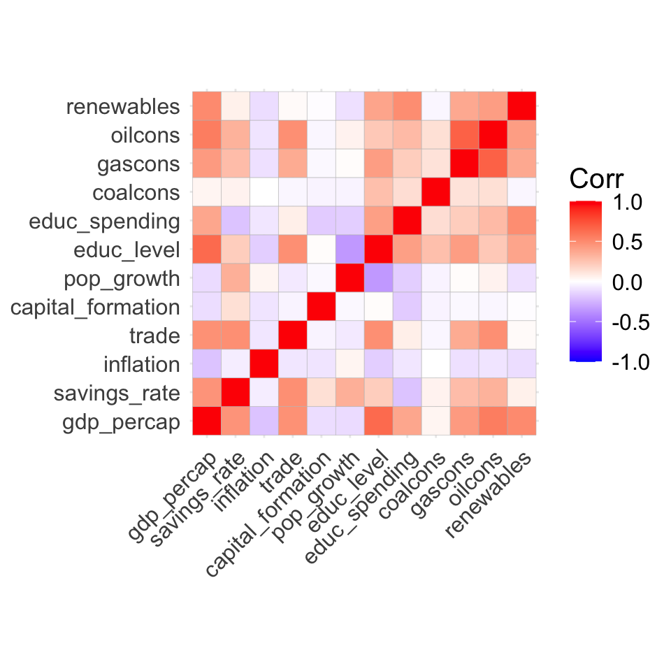

```r
data_join <- data_join |>
  mutate(oilcons = oilcons / pop * 10^9,
         coalcons = coalcons / pop * 10^9,
         gascons = gascons / pop * 10^9,
         renewables = renewables / pop * 10^9) |>
  select(year, country, gdp_growth, coalcons, gascons, oilcons, renewables, vars) |>
  ungroup() |>
  distinct()

cor(data_join |> dplyr::select(all_of(c(vars, "coalcons", "gascons", "oilcons", "renewables"))),
    use = "pairwise.complete") |>
  ggcorrplot() +
  theme(text = element_text(size = 15),
        axis.text = element_text(size = 15))
```

We build a model omitting a few variables.  
(this is just for illustration)

```r
fml_0 <- "gdp_growth ~ gdp_percap + savings_rate + pop_growth + educ_level + coalcons + renewables"
fml <- as.formula(paste(fml_0, "| year + country"))
(feols(fml, data = data_join))$coeftable
```

|  | Estimate | Std. Error | t value | Pr(>\|t\|) |
| --- | --- | --- | --- | --- |
| gdp_percap | 0.0417195 | 0.0162756 | 2.5633239 | 0.0105601 |
| savings_rate | 0.0024491 | 0.0007659 | 3.1976221 | 0.0014434 |
| pop_growth | -0.0225878 | 0.0073137 | -3.0884106 | 0.0020860 |
| educ_level | 0.0000835 | 0.0004855 | 0.1719713 | 0.8635062 |
| coalcons | 0.0002241 | 0.0003797 | 0.5902965 | 0.5551685 |
| renewables | 0.0011278 | 0.0010598 | 1.0641805 | 0.2875872 |

Energy not very significant in the end…

# Convergence?

**Convergence** in economics refers to the idea that poor countries will eventually catch-up with rich ones; that rich countries would stagnate in terms of wealth whereas developing countries, with cheaper labor force would benefit from higher growth rates, resulting in a reduction of inequalities. This line of reasoning may be subject to conditions, naturally.

This is something that we can test, too. First, let’s seen if countries with **low income** have growth rates superior to those with **high income**.

```r
t.test(wb_growth |> filter(income == "High income") |> pull(gdp_growth),
       wb_growth |> filter(income == "Low income") |> pull(gdp_growth))
```

```
    Welch Two Sample t-test

data:  pull(filter(wb_growth, income == "High income"), gdp_growth) and pull(filter(wb_growth, income == "Low income"), gdp_growth)
t = 4.2416, df = 1884, p-value = 2.327e-05
alternative hypothesis: true difference in means is not equal to 0
95 percent confidence interval:
 0.01291440 0.03512813
sample estimates:
 mean of x  mean of y
0.06943830 0.04541704
```

What does this mean?

What about dynamic patterns?

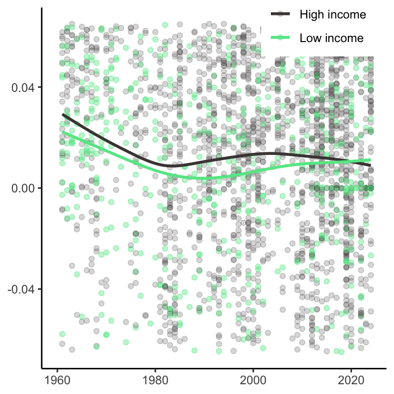

Growth across income groups

```r
wb_growth |>
  filter(income %in% c("High income", "Low income")) |>
  ggplot(aes(x = year, y = gdp_growth, color = income)) +
  geom_point(aes(alpha = income)) + geom_smooth(se = F) +
  theme_classic() +
  theme(legend.position = c(0.8, 0.95),
        legend.title = element_blank(),
        axis.title = element_blank()) +
  scale_color_manual(values = c("#4A4443", "#63E693")) +
  scale_alpha_manual(values = c(0.2, 0.4)) +
  ylim(-0.065, 0.065)
```

- the 1960-2010 period argues **against** convergence;
- the most recent points (2024) indicate a status-quo, or a reversion…?

This is supported by [What Remains of Cross-Country Convergence?](https://www.aeaweb.org/articles?id=10.1257/jel.20181207):

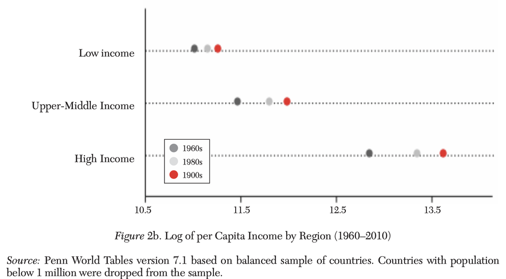

Another related paper: [Growth, Interrupted: How Crises delay Global Convergence](https://www.imf.org/en/Publications/WP/Issues/2025/06/13/Growth-Interrupted-How-Crises-delay-Global-Convergence-567257):

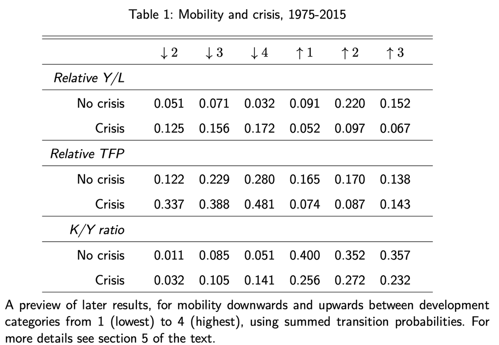

The above table shows the transitions from income groups in periods **with and without crises**. It shows that moving upward (to a higher income group) is much more likely outside crisis periods, but that the probability of moving downwards increases during downturns.

Finally, some additional material from this [post](https://www.chat-gdp.org/we-were-wrong-about-convergence/):

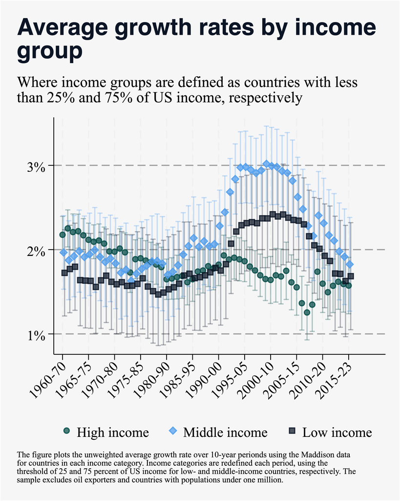

# A step back: heuristic sources of growth

(see [CSV](https://press.lse.ac.uk/site/books/m/10.31389/lsepress.ame/), section 7.2)

- **luck**: initial conditions may have an impact.
- **geography**: natural resources (minerals, grains, cattle, etc.) are a key driver of growth. Diseases are also more frequent in some parts of the globe.
- **culture** (customary beliefs and values): they can drive economic decisions, but are also hard to measure.
- **institutions**: property rights, labor markets, regulation.